# Censored Gaussian Process Regression

## Introduction

The **censoredGP** repository provides R scripts for fitting Gaussian Process (GP) regression models with right-censored responses, with a particular focus on scalable computation for large datasets. Censored responses occur when the true latent response is only partially observed because it exceeds a known censoring threshold. Such data arise in many scientific applications, including engineering reliability, environmental monitoring, and biological experiments.

The proposed censored GP fitting and prediction functions are implemented in `cenGP_fit_pred_functions.R`. The model combines:

- Gaussian Process regression
- likelihood-based treatment of right-censored responses
- Vecchia approximation for scalable computation with large datasets

This vignette demonstrates the complete workflow using a one-dimensional example. The functions used for the one-dimensional manuscript example are provided in `VGP_fit_pred_functions_1d.R`, and the corresponding plot can be reproduced by running `VGP_run_functions.R`. This produces Plot 1, which compares the standard GP model with the proposed censored GP model.

In addition, the main simulation study can be run using `cenGP_run_functions.R`. This script applies the proposed censored GP method to the Borehole 8-dimensional data example and evaluates its prediction performance.

This vignette focuses on the following steps:

1. Simulating censored training and test data
2. Exploring the training data
3. Fitting the proposed censored GP model
4. Generating predictions for new inputs
5. Visualizing the predictions against the true function

The main functions used in this vignette are:

- `simulate_1d_censored_data()`
- `simulate_borehole_censored_data()`
- `fit_censored_gp_nn()`
- `predict_censored_gp_nn_with_censoring()`

## Load Functions

```r
library(ggplot2)

source_file <- "cenGP_fit_pred_functions.R"
if (!file.exists(source_file)) {
  source_file <- "~/Desktop/censoredGP/cenGP_fit_pred_functions.R"
}
source(source_file)
```

## Simulate One-Dimensional Censored Data

```r
sim <- simulate_1d_censored_data(
  n = 800,
  split_method = "id",
  n_test_grid = 100,
  threshold_C = 1.221277,
  seed = 2024,
  seed_split = 2024,
  noise_sd = 0.2,
  reps_min = 1,
  reps_max = 3
)

train_data <- sim$train_data
test_data <- sim$test_data
C <- sim$threshold_C
f <- default_1d_fun
test_data <- make_1d_test_grid(n_test = 100, threshold_C = C, f = f)
```

The simulated training data contains both the raw noisy response and the censored observed response:

- `x1`: input location
- `y`: raw noisy response before censoring, available because this is simulated data
- `y_censored`: observed response after right-censoring
- `censored`: indicator, where `1` means the row is censored
- `ID`: replicate group ID

For fitting the censored model, use the observed censored response as `y`. We keep the raw noisy value in `y_raw` only for diagnostics and plotting.

```r
train_fit <- train_data
train_fit$y_raw <- train_fit$y
train_fit$y <- train_fit$y_censored

head(train_fit)
```

```
#>          x1         y ID y_censored censored     y_raw
#> 1 0.8369425 1.2212770  1  1.2212770        1 1.4499387
#> 2 0.8369425 1.2212770  1  1.2212770        1 1.8793633
#> 3 0.8369425 1.2212770  1  1.2212770        1 2.1397581
#> 4 0.3208675 0.7939018  2  0.7939018        0 0.7939018
#> 5 0.6803633 0.5735816  3  0.5735816        0 0.5735816
#> 6 0.6803633 0.3394685  3  0.3394685        0 0.3394685
```

```r
table(train_fit$censored)
```

```
#>
#>   0   1
#> 675 428
```

## Explore The Training Data

Before fitting the model it is useful to visualize what the training data looks like, and to understand how censoring affects the observed responses. We first define the true underlying function `f(x)` used to generate the data:

```r
f <- function(x) {
  sin(2 * (7 * x - 2)) + 3 * exp(-15^2 * (x - 0.5)^2) + sin(2 * (2 * x - 0.5))
}
```

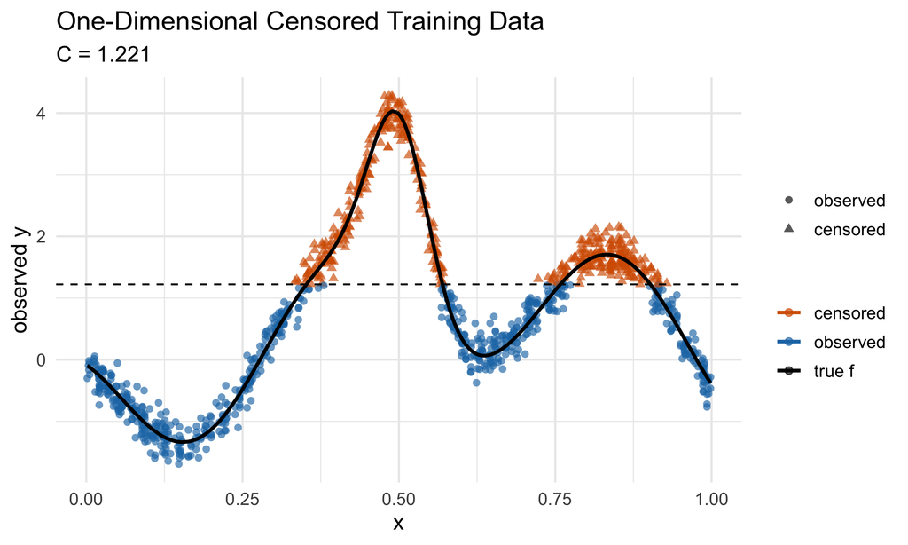

```r
train_plot <- train_fit
train_plot$censor_status <- factor(
  train_plot$censored,
  levels = c(0, 1),
  labels = c("observed", "censored")
)

p0 <- ggplot(train_plot, aes(x = x1)) +
  geom_point(
    aes(y = y_raw, color = censor_status, shape = censor_status),
    alpha = 0.65,
    size = 1.8
  ) +
  geom_line(aes(y = f(x1), color = "true f"), linewidth = 1) +
  geom_hline(yintercept = C, linetype = "dashed") +
  labs(
    title = "One-Dimensional Censored Training Data",
    subtitle = sprintf("C = %.3f", C),
    x = "x",
    y = "observed y",
    color = NULL,
    shape = NULL
  ) +
  scale_color_manual(
    values = c(
      observed = "#1f77b4",
      censored = "#D55E00",
      "true f" = "black"
    )
  ) +
  scale_shape_manual(values = c(observed = 16, censored = 17)) +
  theme_minimal(base_size = 13)

print(p0)
```

## Fit The Censored GP Model

Choose the censored probability method here. For example:

```r
censor_method <- "sov"
```

Other options include:

```r
censor_method <- "mc-sov"
censor_method <- "miwa"
censor_method <- "genzbretz"
censor_method <- "met"
```

We estimate the model parameters by maximizing the censored likelihood using `fit_censored_gp_nn()`.

```r
fit <- fit_censored_gp_nn(
  train_data = train_fit,
  x_cols = "x1",
  threshold_C = C,
  y_col = "y",
  censored_col = "censored",
  id_col = "ID",
  k = 20,
  init_params = c(
    tau_sq = 0.3462413,
    ell_x1 = 1.5,
    sigma_sq = 0.02911056,
    beta_Intercept = 0.01410213
  ),
  lower_bounds = c(
    tau_sq = 1e-6,
    ell_x1 = 1e-6,
    sigma_sq = 1e-6,
    beta_Intercept = -Inf
  ),
  upper_bounds = c(
    tau_sq = Inf,
    ell_x1 = Inf,
    sigma_sq = Inf,
    beta_Intercept = Inf
  ),
  censor_method = censor_method,
  use_parallel = TRUE,
  optim_control = list(maxit = 200),
  return_prepared = TRUE
)
```

The key arguments controlling the model fitting are:

- `train_data` — the training dataset containing both censored and uncensored observations on which the GP is fitted
- `threshold_C` — the censoring threshold
- `x_cols = "x1"` — the column(s) in `train_data` used as input features for the GP covariance structure
- `init_params` — initial values for the hyperparameters (e.g. signal variance, length-scale, noise variance, and mean) passed to the optimizer
- `lower_bounds` — lower bounds for the hyperparameter optimization; the first three parameters are constrained to be strictly positive while the last (mean) is unconstrained
- `upper_bounds` — upper bounds for the hyperparameter optimization; all four parameters are unconstrained from above
- `k` — the number of nearest neighbors used in the local GP approximation during fitting, controlling the trade-off between computational efficiency and model fidelity

Inspect the fitted model and the estimated parameters are stored in `fit$estimated_params`:

```r
fit
```

```
#> Censored GP nearest-neighbor fit
#> Dimension: 1
#> Predictors: x1
#> Censored probability method: sov
#> Threshold C: 1.221277
#> Neighbors k: 20
#> Used parallel optimization: TRUE
#> Estimated parameters:
#>         tau_sq         ell_x1       sigma_sq beta_Intercept
#>     8.03788980     0.14687060     0.03476117     5.41648595
#> Final log-likelihood: -22.42993
#> Counts:
#> function gradient
#>       61       61
#> Optim elapsed seconds: 66.811
```

```r
fit$estimated_params
```

```
#>         tau_sq         ell_x1       sigma_sq beta_Intercept
#>     8.03788980     0.14687060     0.03476117     5.41648595
```

```r
fit$final_log_likelihood
```

```
#> [1] -22.42993
```

```r
fit$optim_time
```

```
#>    user  system elapsed
#>   0.266   0.449  66.811
```

```r
fit$total_seconds
```

```
#> [1] 67.09363
```

```r
fit$used_parallel
```

```
#> [1] TRUE
```

These four values correspond to:

- `tau_sq` — signal variance: controls the overall scale of variability in the latent GP function
- `ell` — length-scale: larger values mean the function varies more slowly over the input space
- `sigma_sq` — noise variance: the nugget term accounting for measurement error
- `beta0` — mean function: intercept of the constant prior mean function; when the response has been centered or no prior trend is expected, this is typically set to 0

## Prediction

The test data is the fixed 100-point grid:

```r
head(test_data)
```

```
#>           x1           y ID  y_censored censored
#> 1 0.00000000 -0.08466849  1 -0.08466849        0
#> 2 0.01010101 -0.16183861  2 -0.16183861        0
#> 3 0.02020202 -0.25079116  3 -0.25079116        0
#> 4 0.03030303 -0.34931306  4 -0.34931306        0
#> 5 0.04040404 -0.45497636  5 -0.45497636        0
#> 6 0.05050505 -0.56518751  6 -0.56518751        0
```

```r
tail(test_data)
```

```
#>            x1           y  ID  y_censored censored
#> 95  0.9494949  0.46835793  95  0.46835793        0
#> 96  0.9595960  0.28901885  96  0.28901885        0
#> 97  0.9696970  0.10938337  97  0.10938337        0
#> 98  0.9797980 -0.06767334  98 -0.06767334        0
#> 99  0.9898990 -0.23933537  99 -0.23933537        0
#> 100 1.0000000 -0.40290110 100 -0.40290110        0
```

Use the censoring-adjusted prediction function `predict_censored_gp_nn_with_censoring()`. This conditions on nearby uncensored and censored training IDs and uses truncated-normal moments for censored neighbors.

```r
pred <- predict_censored_gp_nn_with_censoring(
  fit = fit,
  test_data = test_data,
  k = 20,
  max_censored_ids = 5,
  min_uncensored_ids = 15,
  distance_method = "euclidean",
  moment_method = "tmvtnorm",
  predict_y = TRUE,
  n_pred_samples = 20000,
  sample_method = "TruncatedNormal",
  prediction_seed = 123,
  interval_level = 0.95,
  unique_test_inputs = TRUE,
  verbose = FALSE
)

pred$average_interval
```

```
#> [1] 0.9160904
```

```r
head(pred$results_df)
```

```
#>   ID_test  mean_pred   var_pred sample_mean sample_var   CI_lower    CI_upper
#> 1       1 -0.0565998 0.04138638  -0.0565998 0.04138638 -0.4553279  0.34212828
#> 2       2 -0.1896147 0.03671580  -0.1896147 0.03671580 -0.5651706  0.18594124
#> 3       3 -0.2871950 0.03569055  -0.2871950 0.03569055 -0.6574703  0.08308025
#> 4       4 -0.3852831 0.03568646  -0.3852831 0.03568646 -0.7555372 -0.01502906
#> 5       5 -0.5029378 0.03562845  -0.5029378 0.03562845 -0.8728908 -0.13298480
#> 6       6 -0.5981471 0.03567715  -0.5981471 0.03567715 -0.9683529 -0.22794138
#>   interval_length    interval_method moment_method n_pred_samples n_total
#> 1       0.7974562 Gaussian quantiles    not needed              0      20
#> 2       0.7511118 Gaussian quantiles    not needed              0      20
#> 3       0.7405505 Gaussian quantiles    not needed              0      20
#> 4       0.7405081 Gaussian quantiles    not needed              0      20
#> 5       0.7399060 Gaussian quantiles    not needed              0      20
#> 6       0.7404115 Gaussian quantiles    not needed              0      20
#>   n_cens n_uncens
#> 1      0       20
#> 2      0       20
#> 3      0       20
#> 4      0       20
#> 5      0       20
#> 6      0       20
```

```r
head(pred$merged_df)
```

```
#>   ID         x1           y  y_censored censored  mean_pred   var_pred
#> 1  1 0.00000000 -0.08466849 -0.08466849        0 -0.0565998 0.04138638
#> 2  2 0.01010101 -0.16183861 -0.16183861        0 -0.1896147 0.03671580
#> 3  3 0.02020202 -0.25079116 -0.25079116        0 -0.2871950 0.03569055
#> 4  4 0.03030303 -0.34931306 -0.34931306        0 -0.3852831 0.03568646
#> 5  5 0.04040404 -0.45497636 -0.45497636        0 -0.5029378 0.03562845
#> 6  6 0.05050505 -0.56518751 -0.56518751        0 -0.5981471 0.03567715
#>   sample_mean sample_var   CI_lower    CI_upper interval_length
#> 1  -0.0565998 0.04138638 -0.4553279  0.34212828       0.7974562
#> 2  -0.1896147 0.03671580 -0.5651706  0.18594124       0.7511118
#> 3  -0.2871950 0.03569055 -0.6574703  0.08308025       0.7405505
#> 4  -0.3852831 0.03568646 -0.7555372 -0.01502906       0.7405081
#> 5  -0.5029378 0.03562845 -0.8728908 -0.13298480       0.7399060
#> 6  -0.5981471 0.03567715 -0.9683529 -0.22794138       0.7404115
#>      interval_method moment_method n_pred_samples
#> 1 Gaussian quantiles    not needed              0
#> 2 Gaussian quantiles    not needed              0
#> 3 Gaussian quantiles    not needed              0
#> 4 Gaussian quantiles    not needed              0
#> 5 Gaussian quantiles    not needed              0
#> 6 Gaussian quantiles    not needed              0
```

## Visualize Predictions

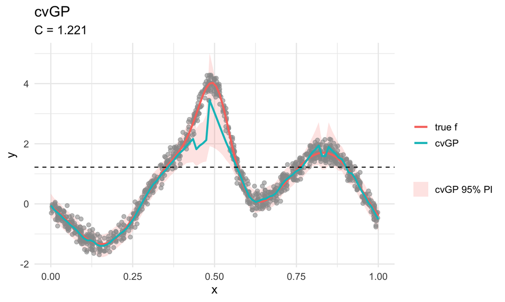

```r
cGP <- pred$merged_df
cGP$true_f <- f(cGP$x1)

p1 <- ggplot(cGP, aes(x = x1)) +
  geom_ribbon(aes(ymin = CI_lower, ymax = CI_upper, fill = "cvGP 95% PI"),
              alpha = 0.18) +
  geom_point(data = train_data, aes(x = x1, y = y),
             color = "grey60", alpha = 0.6, size = 1.8)+
  # ---- correct mappings for legend labels/colors ----
geom_line(aes(y = f(x1),  color = "true f"), linewidth = 1) +   # true f line -> "true f"
  geom_line(aes(y = mean_pred, color = "cvGP"),  linewidth = 1) +    # model line -> "cvGP"
  geom_hline(yintercept = C, linetype = "dashed") +
  labs(
    title = "cvGP",
    subtitle = sprintf("C = %.3f", C),
    x = "x", y = "y", color = NULL, fill = NULL
  ) +
  theme_minimal(base_size = 13) +
scale_color_manual(values = c("true f" = "#F8766D",   # ggplot2 default red
                              "cvGP"   = "#00BFC4"),  # ggplot2 default blue/teal
                   breaks = c("true f", "cvGP")) +
  scale_fill_manual(values = c("cvGP 95% PI" = "#F8766D33")) +  # light red ribbon
  guides(
    color = guide_legend(order = 1),  # lines first
    fill  = guide_legend(order = 2)   # ribbon below
  )
print(p1)
```

## Simple Prediction Without Censored-Neighbor Moment Adjustment

For comparison, the simpler predictor uses only uncensored training rows:

```r
pred_simple <- predict_censored_gp_nn(
  fit = fit,
  test_data = test_data,
  max_marker_neighbors = 20,
  interval_level = 0.95,
  include_noise = TRUE
)

head(pred_simple)
```

```
#>   test_index predicted_mean predicted_variance   CI_lower    CI_upper
#> 1          1     -0.0565998         0.04138637 -0.4553278  0.34212822
#> 2          2     -0.1896147         0.03671579 -0.5651705  0.18594118
#> 3          3     -0.2871950         0.03569054 -0.6574702  0.08308020
#> 4          4     -0.3852831         0.03568645 -0.7555371 -0.01502912
#> 5          5     -0.5029378         0.03562844 -0.8728908 -0.13298485
#> 6          6     -0.5981471         0.03567714 -0.9683528 -0.22794143
#>   interval_length
#> 1       0.7974560
#> 2       0.7511117
#> 3       0.7405504
#> 4       0.7405080
#> 5       0.7399059
#> 6       0.7404114
```

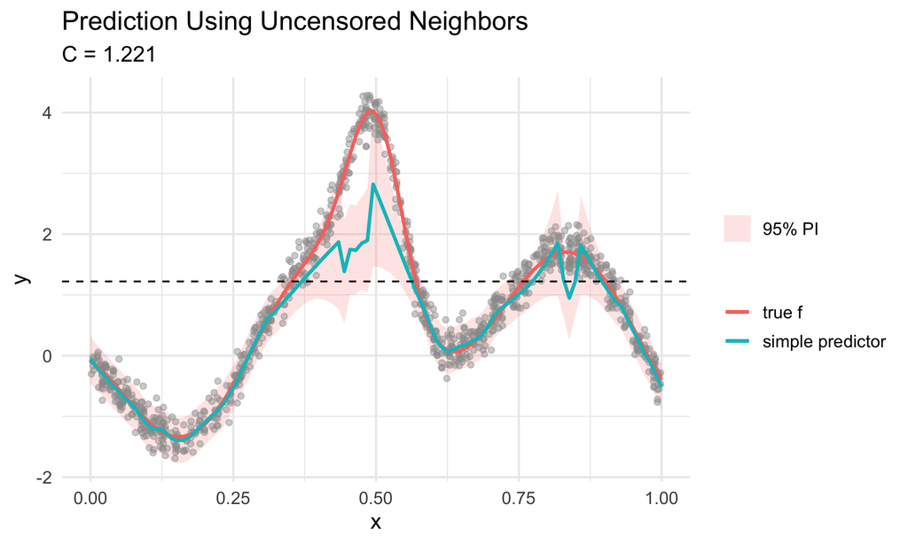

```r
simple_df <- test_data
simple_df$predicted_mean <- pred_simple$predicted_mean
simple_df$CI_lower <- pred_simple$CI_lower
simple_df$CI_upper <- pred_simple$CI_upper
simple_df$true_f <- f(simple_df$x1)

p2 <- ggplot(simple_df, aes(x = x1)) +
  geom_ribbon(
    aes(ymin = CI_lower, ymax = CI_upper, fill = "95% PI"),
    alpha = 0.18
  ) +
  geom_point(
    data = train_fit,
    aes(x = x1, y = y_raw),
    color = "grey60",
    alpha = 0.45,
    size = 1.4,
    inherit.aes = FALSE
  ) +
  geom_line(aes(y = true_f, color = "true f"), linewidth = 1) +
  geom_line(aes(y = predicted_mean, color = "simple predictor"), linewidth = 1) +
  scale_color_manual(
    values = c(
      "true f" = "#F8766D",
      "simple predictor" = "#00BFC4"
    ),
    breaks = c("true f", "simple predictor")
  ) +
  geom_hline(yintercept = C, linetype = "dashed") +
  labs(
    title = "Prediction Using Uncensored Neighbors",
    subtitle = sprintf("C = %.3f", C),
    x = "x",
    y = "y",
    color = NULL,
    fill = NULL
  ) +
  theme_minimal(base_size = 13)

print(p2)
```